# TestCode

Shubham Gupta

September 7, 2016

## Bioinformatician Data Assignment

Clean the global environment and set up plot settings

```r
rm(list = ls())
tropical=  c('darkorange', 'dodgerblue', 'hotpink', 'limegreen', 'yellow')
palette(tropical)
par(pch = 19)
```

### Load libraries

```r
library(ggplot2)
library(tidyjson)
library(dplyr)
library(jsonlite)
library(DBI)
library(RMySQL)
```

### Question 1

First load the Json data unflattened

```r
setwd("C:/Users/shubh/OneDrive/Documents/data-viz-challenge-master/")
testData1 <- fromJSON("data.json")
class(testData1)
```

```
## [1] "list"
```

```r
names(testData1)
```

```
## [1] "data"
```

```r
class(testData1$data)
```

```
## [1] "data.frame"
```

**Read the metrics of data and other properties**

```r
names(testData1$data)
```

```
##  [1] "category"       "event_name"     "gender"         "age"
##  [5] "marital_status" "session_id"     "device"         "client_time"
##  [9] "location"       "amount"
```

```r
dim(testData1$data)
```

```
## [1] 50000    10
```

```r
head(testData1$data, n = 5)
```

```
##      category   event_name gender   age marital_status
## 1      Sports View Project      M 18-24        married
## 2  Technology View Project      M 18-24         single
## 3 Environment View Project      M   55+         single
## 4  Technology View Project      M 18-24         single
## 5      Sports View Project      F 25-34        married
##                         session_id  device client_time location.latitude
## 1 69f62d2ae87640f5a2dde2b2e9229fe6 android  1393632004          40.18979
## 2 4459d001feb8438eae5f4ec24abcd992     iOS  1393632022          33.84437
## 3 0db9ed700a184d48a9d04806696e3642     iOS  1393632032          42.44640
## 4 68195e2372bd4022b17220fc21de9138 android  1393632038          44.62441
## 5 9508a8385dc94773baba8aa7d1c2aa75     iOS  1393632051          36.74708
##   location.city location.state location.longitude location.zip_code amount
## 1         Lyons             CO         -105.35528             80540     NA
## 2    Alpharetta             GA          -84.47405             30009     NA
## 3      Westford             MA          -71.45941             01886     NA
## 4       Saranac             NY          -73.80927             12981     NA
## 5         Lampe             MO          -93.45863             65681     NA
```

```r
table(testData1$data$category)
```

```
##
## Environment     Fashion       Games      Sports  Technology
##        9980        9937        9955       10099       10029
```

```r
table(testData1$data$event_name)
```

```
##
## Fund Project View Project
##        20658        29342
```

```r
table(testData1$data$gender)
```

```
##
##     F     M
## 24994 25006
```

```r
table(testData1$data$age)
```

```
##
## 18-24 25-34 35-44 45-54   55+
## 24395  6231  6676  6392  6306
```

```r
table(testData1$data$marital_status)
```

```
##
## married  single
##   32083   17917
```

```r
dim(unique(testData1$data[6]))[1] # Counting number of users(unique) who responded
```

```
## [1] 10466
```

```r
dim(testData1$data[6])[1] # It shows that users have responded multiple times
```

```
## [1] 50000
```

```r
table(testData1$data$device)
```

```
##
## android     iOS
##   17713   32287
```

```r
testData1$data$client_time[1:19] # Looking at time to see the format
```

```
##  [1] 1393632004 1393632022 1393632032 1393632038 1393632051 1393632064
##  [7] 1393632137 1393632138 1393632145 1393632159 1393632160 1393632162
## [13] 1393632171 1393632184 1393632188 1393632199 1393632200 1393632211
## [19] 1393632211
```

```r
summary(testData1$data$amount)
```

```
##    Min. 1st Qu.  Median    Mean 3rd Qu.    Max.    NA's
##    1.00   29.00   39.00   39.41   50.00  101.00   29342
```

```r
class(testData1$data$location)
```

```
## [1] "data.frame"
```

```r
names(testData1$data$location)
```

```
## [1] "latitude"  "city"      "state"     "longitude" "zip_code"
```

```r
sort(table(testData1$data$location$state), decreasing = TRUE) # Number hits from each state
```

```
##
##   IN   GA   OR   CO   CA   TX   FL   NY   OH   IL   PA   MI   NC   VA   NJ
## 8909 7586 6516 5294 2823 1957 1489 1450  971  941  906  709  692  642  592
##   MA   TN   MD   WI   MO   WA   AL   AZ   SC   KY   MN   OK   LA   CT   IA
##  512  507  474  463  458  452  451  438  419  404  357  340  301  289  230
##   AR   NE   UT   KS   NV   NM   MS   ID   RI   WV   DE   MT   HI   SD   VT
##  227  223  219  211  191  156  144  127  115  101   96   96   87   85   72
##   ME   NH   ND   WY   AK   DC
##   66   65   57   37   29   24
```

**Test Schema**

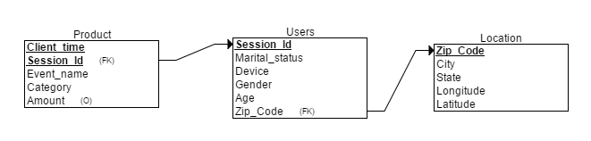

### Send data to MYSQL

```r
mydb = dbConnect(MySQL(), user='root', password='TestCode', dbname='testdatadb', host='localhost')
dbListTables(mydb)
```

```
## [1] "location" "product"  "users"
```

```r
dbSendQuery(mydb, 'drop table if exists location, users, product')
```

```
## <MySQLResult:2033544,0,1>
```

```r
dbWriteTable(mydb, name='location', value = subset(testData1$data$location,  !(duplicated(testData1$data$location))))
```

```
## [1] TRUE
```

```r
users_df = subset(testData1$data, select=c(session_id , marital_status, device, gender, age))
users_df["zip_code"] <- testData1$data$location$zip_code
dbWriteTable(mydb, name='users', value = users_df)
```

```
## [1] TRUE
```

```r
product_df = subset(testData1$data, select=c(client_time, session_id , event_name, category, amount))
product_df$amount[is.na(product_df$amount)] <- 'NULL'
dbWriteTable(mydb, name='product', value = product_df)
```

```
## [1] TRUE
```

```r
dbListTables(mydb)
```

```
## [1] "location" "product"  "users"
```

```r
rs = dbSendQuery(mydb, "select * FROM location")
dat = fetch(rs, n=-1)
dat[1:5,]
```

```
##   row_names latitude       city state  longitude zip_code
## 1         1 40.18979      Lyons    CO -105.35528    80540
## 2         2 33.84437 Alpharetta    GA  -84.47405    30009
## 3         3 42.44640   Westford    MA  -71.45941    01886
## 4         4 44.62441    Saranac    NY  -73.80927    12981
## 5         5 36.74708      Lampe    MO  -93.45863    65681
```

```r
dbDisconnect(mydb)
```

```
## [1] TRUE
```

### Visualize the data using plot and ggplot2

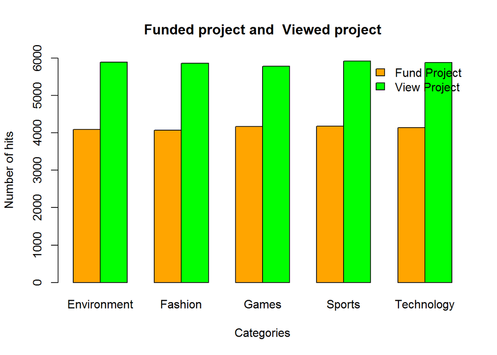

```r
counts <- table(testData1$data$event_name, testData1$data$category)
barplot(counts, main="Funded project and  Viewed project", xlab="Categories", ylab="Number of hits", col=c("orange","green"), beside=TRUE, ylim = c(0,6000))
legend("topright", legend = rownames(counts), fill = c("orange","green"), bty = "n")
```

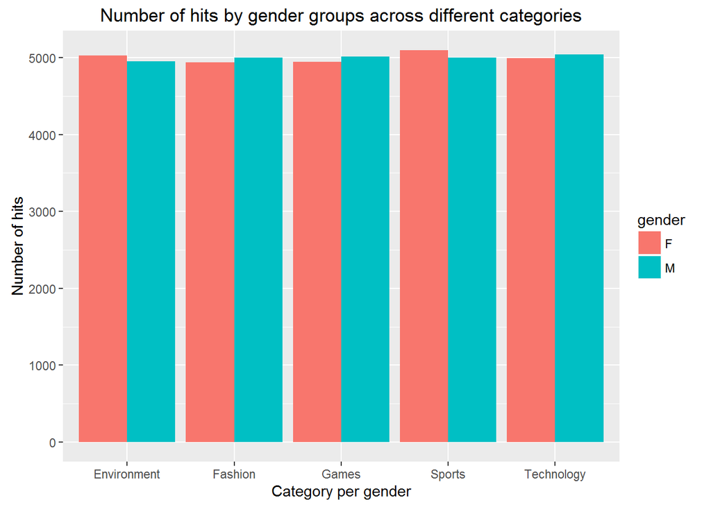

```r
ggplot(data=testData1$data, aes(x=category, fill= gender)) + geom_bar(stat="count", position = position_dodge()) +  ggtitle("Number of hits by gender groups across different categories") + xlab("Category per gender") + ylab("Number of hits")
```

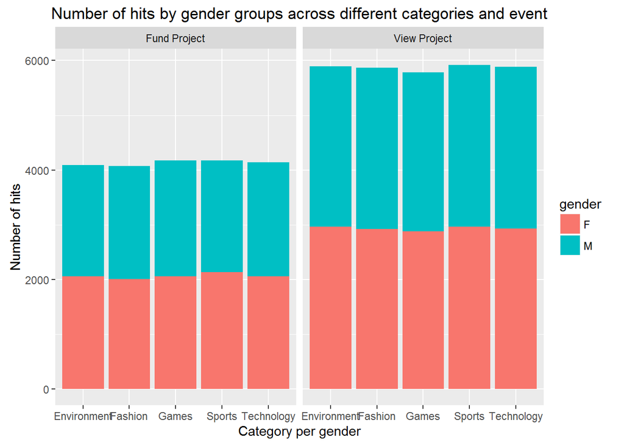

```r
ggplot(data=testData1$data, aes(x= category, fill= gender)) + geom_bar(stat="count", position = "stack")  + facet_wrap( ~ event_name) + xlab("Category per gender") + ylab("Number of hits") + ggtitle("Number of hits by gender groups across different categories and event")
```

There is no significant difference between number of hits for funded projects across gender groups and categories. Its ratio to viewed projects across different gender groups reflects the same. There is also no considerable difference in inclination towards getting response by either male or female.

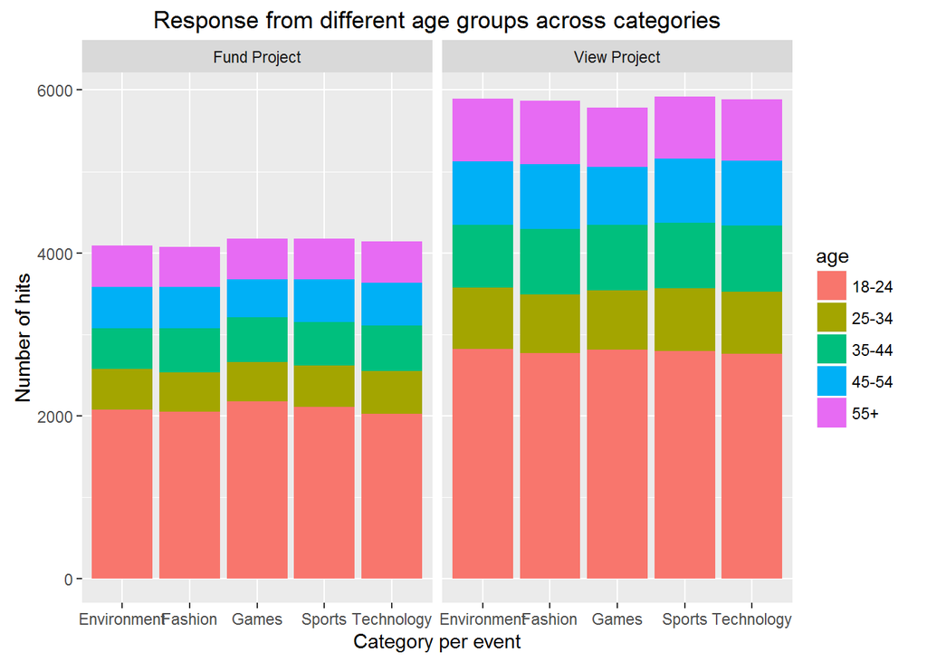

```r
ggplot(data=testData1$data, aes(x= category, fill= age)) + geom_bar(stat="count", position = "stack")  + facet_wrap( ~ event_name) + xlab("Category per event") + ylab("Number of hits") + ggtitle("Response from different age groups across categories")
```

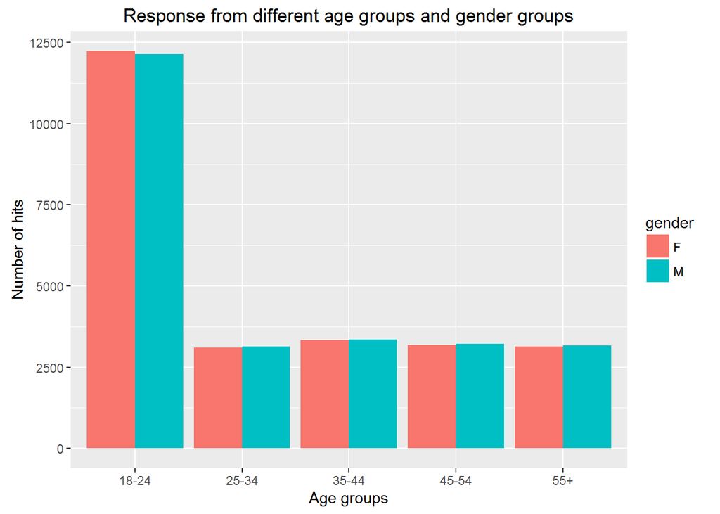

```r
ggplot(data=testData1$data, aes(x=age, fill= gender)) + geom_bar(stat="count", position = position_dodge()) + xlab("Age groups") + ylab("Number of hits") + ggtitle("Response from different age groups and gender groups")
```

We can see that 18-24 age group is very responsive towards all of the categories. There is only a little variation in response pattern for 24+ groups across different sex as well.

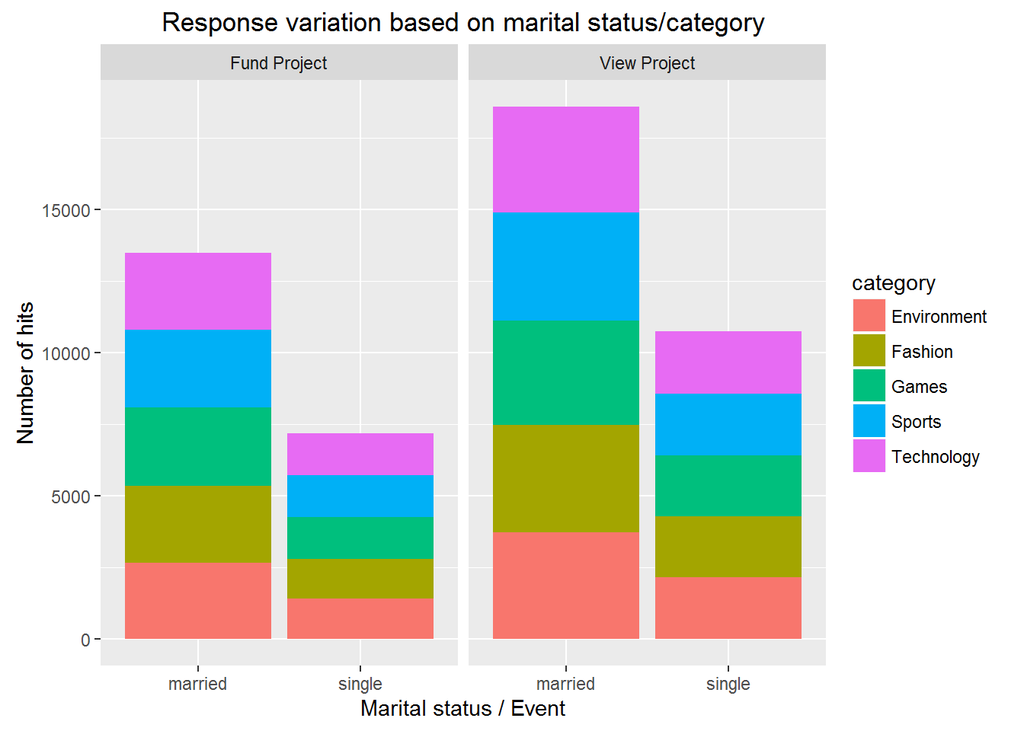

```r
ggplot(data=testData1$data, aes(x= marital_status, fill= category)) + geom_bar(stat="count", position = "stack")  + facet_wrap( ~ event_name) + xlab("Marital status / Event") + ylab("Number of hits") + ggtitle("Response variation based on marital status/category")
```

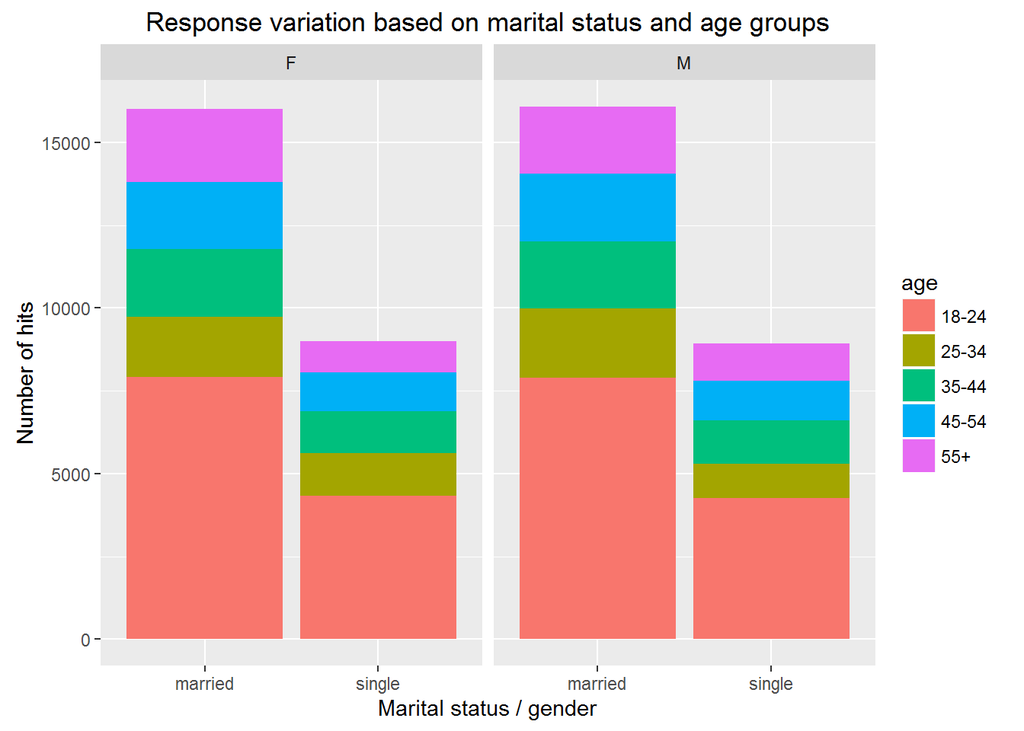

```r
ggplot(data=testData1$data, aes(x= marital_status, fill= age)) + geom_bar(stat="count", position = "stack")  + facet_wrap( ~ gender) + xlab("Marital status / gender") + ylab("Number of hits")  + ggtitle("Response variation based on marital status and age groups")
```

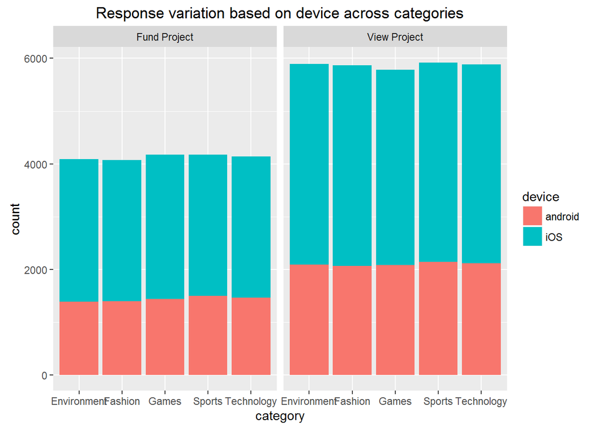

```r
ggplot(data=testData1$data, aes(x= category, fill= device)) + geom_bar(stat="count", position = "stack")  + facet_wrap( ~ event_name) + ggtitle("Response variation based on device across categories")
```

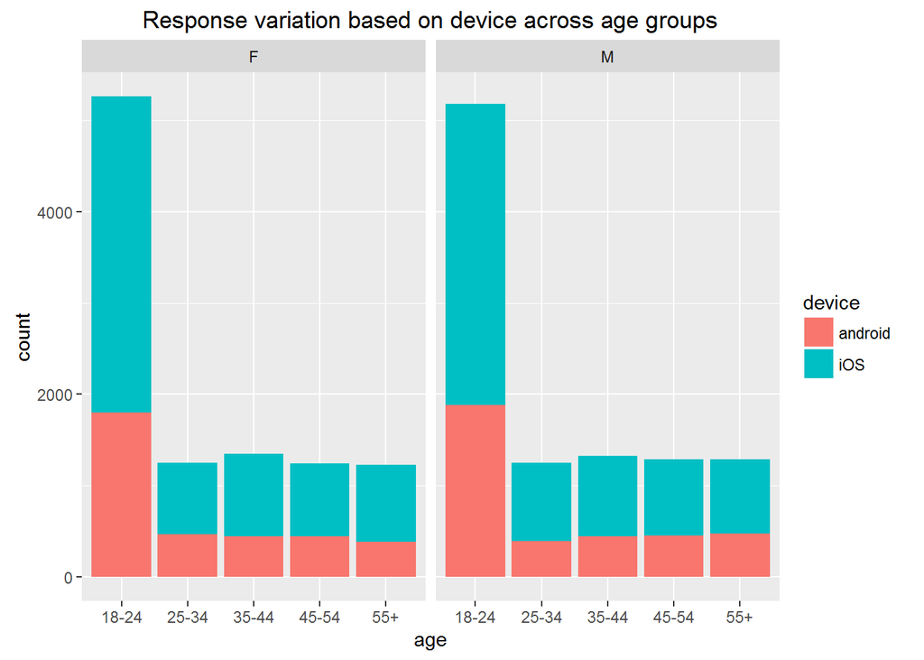

```r
ggplot(data=testData1$data, aes(x= age, fill= device)) + geom_bar(data=subset(testData1$data, event_name =="Fund Project"), stat="count", position = "stack")  + facet_wrap( ~ gender) + ggtitle("Response variation based on device across age groups")
```

Across different marital status, we can say that married people are more responsive than single persons. We also get almost double response from iOS users compared to android users.

```r
counts <- table(testData1$data$event_name, testData1$data$location$state)
rownames(counts) # Getting number of hits for View project and Fund project across all states
```

```
## [1] "Fund Project" "View Project"
```

```r
sort(counts[1,], decreasing = TRUE)
```

```
##   IN   GA   OR   CO   CA   TX   FL   NY   OH   IL   PA   MI   NC   VA   NJ
## 3873 3281 2838 2297 1098  757  572  560  390  355  351  269  264  261  221
##   MA   TN   MD   AL   WA   WI   MO   AZ   KY   SC   MN   OK   LA   CT   NE
##  202  196  192  178  176  174  172  163  163  163  136  132  118  106   89
##   UT   AR   IA   KS   NV   NM   MS   ID   RI   DE   MT   WV   HI   VT   SD
##   87   85   85   79   66   62   52   49   48   41   37   36   34   30   28
##   ME   ND   NH   WY   AK   DC
##   22   21   18   15   11    5
```

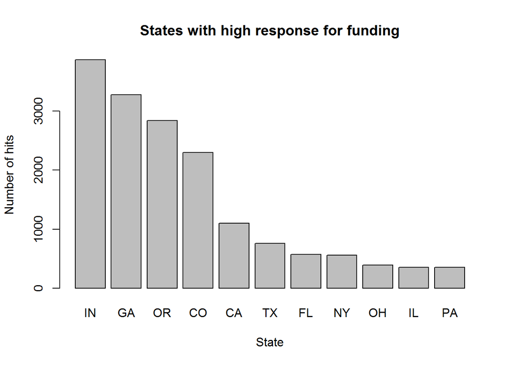

```r
Filt_count = counts[1,counts[1,]>300]
barplot(sort(Filt_count, decreasing = TRUE), main="States with high response for funding", xlab="State", ylab="Number of hits")
```

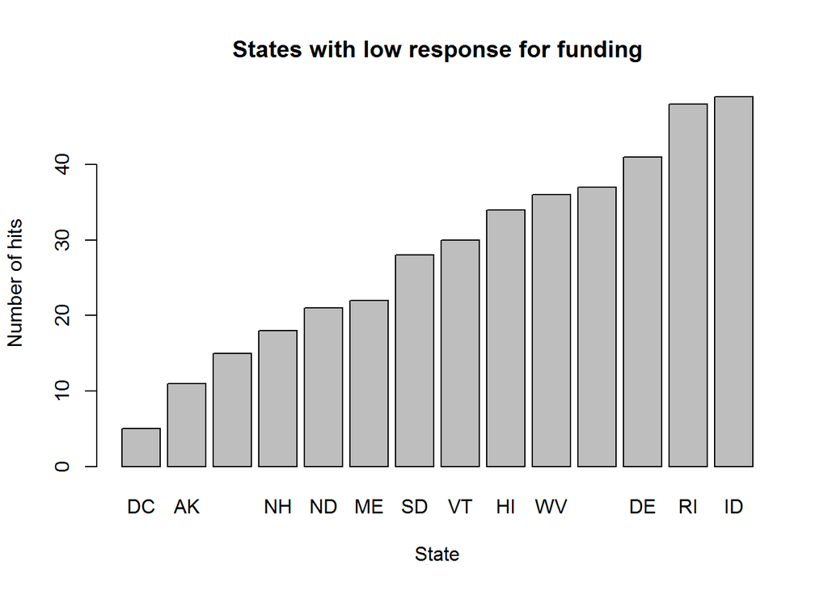

```r
Filt_count_low = counts[1,counts[1,]<50]
barplot(sort(Filt_count_low), main="States with low response for funding", xlab="State", ylab="Number of hits")
```

Highest response for funding is from Indiana (IN) and lowest response is from DC state.

```r
user_count <- count(testData1$data, session_id) #Getting number of hits per user
class(user_count)
```

```
## [1] "tbl_df"     "tbl"        "data.frame"
```

```r
user_counts<- apply(user_count[,2], 1, as.numeric)
class(user_counts)
```

```
## [1] "numeric"
```

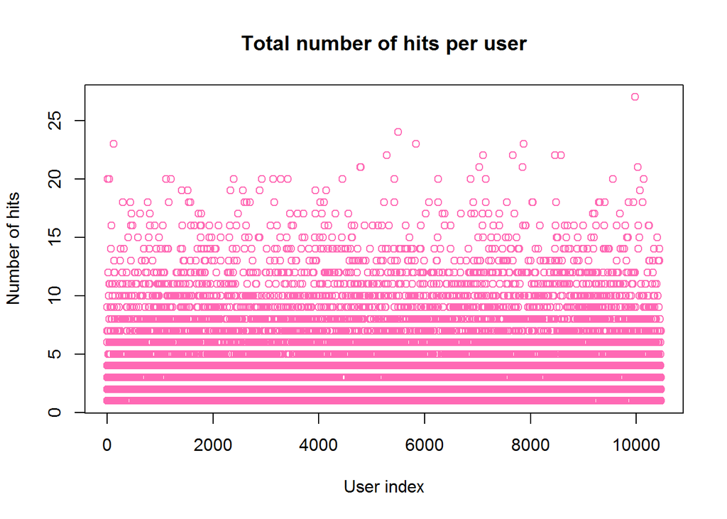

```r
plot(user_counts, col = 3, xlab = 'User index', ylab = 'Number of hits', main="Total number of hits per user")
```

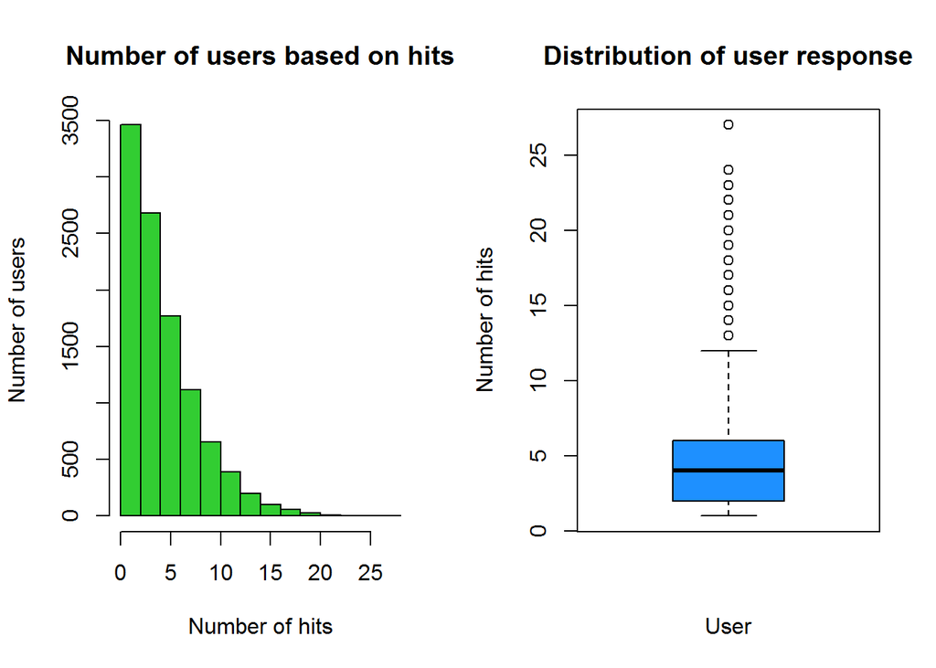

```r
par(mfrow = c(1,2))
hist(user_counts, col = 4, breaks = 10, xlab = 'Number of hits', ylab = 'Number of users', main = "Number of users based on hits")
boxplot(user_counts, col = 2, xlab = 'User', ylab = 'Number of hits', main = "Distribution of user response")
```

```r
c(min(user_counts), median(user_counts), max(user_counts))
```

```
## [1]  1  4 27
```

```r
# as.character(user_count[which.max(user_counts),1])
```

The minimum, median and maximum user response are 1, 4 and 27, respectively.This box plot suggests us 13 outliers for session_ids statistically.

```r
x<-as.factor(table(testData1$data$event_name))
c(x[1], x[2])
```

```
## Fund Project View Project
##            1            2
```

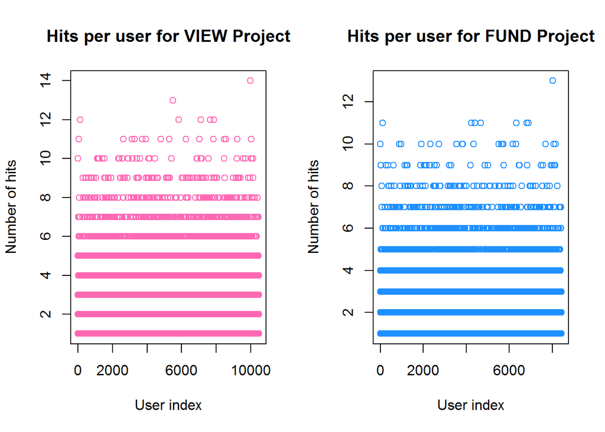

```r
user_count_view <- count(subset(testData1$data, event_name == labels(x[2])), session_id)
user_count_fund <- count(subset(testData1$data, event_name == labels(x[1])), session_id)
user_counts_view<- apply(user_count_view[,2], 1, as.numeric)
user_counts_fund<- apply(user_count_fund[,2], 1, as.numeric)
par(mfrow = c(1,2))
plot(user_counts_view, col = 3, xlab = 'User index', ylab = 'Number of hits', main = "Hits per user for VIEW Project")
plot(user_counts_fund, col = 2, xlab = 'User index', ylab = 'Number of hits',  main = "Hits per user for FUND Project")
```

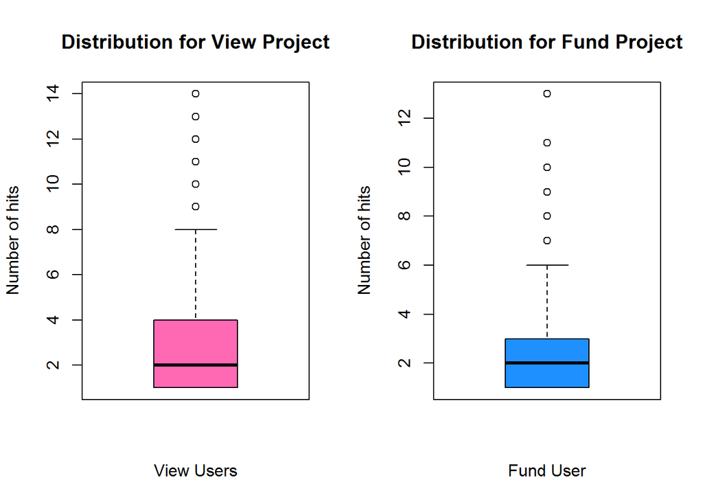

```r
boxplot(user_counts_view, col = 3, xlab = 'View Users', ylab = 'Number of hits', main = "Distribution for View Project")
boxplot(user_counts_fund, col = 2, xlab = 'Fund User', ylab = 'Number of hits', main = "Distribution for Fund Project")
```

```r
c(median(user_counts_view), median(user_counts_fund))
```

```
## [1] 2 2
```

Median value, which is 2, is the same for fund event and view event for number of hits by each user.

**Understanding relation between number of users per category for funded projects only**

```r
subData <- subset(testData1$data, event_name =="Fund Project") #Considering only funded projects
group_by(subData, category,session_id) %>% summarise(newvar = n()) %>% summarise(newvar2 = n())
```

```
## # A tibble: 5 x 2
##      category newvar2
##         <chr>   <int>
## 1 Environment    3256
## 2     Fashion    3243
## 3       Games    3350
## 4      Sports    3296
## 5  Technology    3248
```

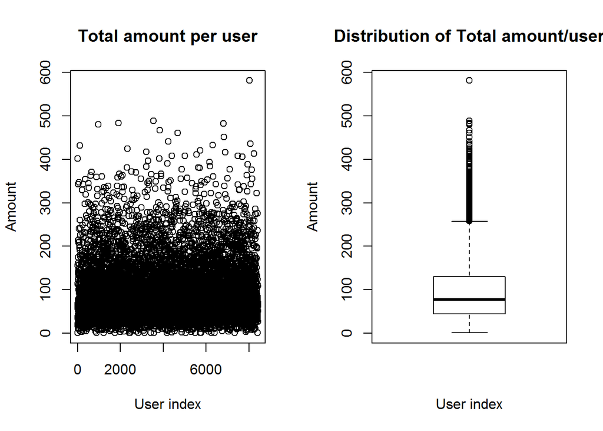

```r
y <- group_by(subData, session_id) %>% summarise(Fund = sum(amount))
x<- (1:dim(y)[1])
y<- apply(y[,2], 1, as.numeric)
par(mfrow = c(1,2))
plot(x,y, xlab = "User index", ylab = "Amount", main = "Total amount per user")
boxplot(y, xlab = "User index", ylab = "Amount", main = "Distribution of Total amount/user")
```

```r
c(median(y), mean(y)) # Mean and median of total amount contribution per user
```

```
## [1] 78.00000 96.71736
```

Previously, We had seen that number of hits per category was almost same. Here, we see that each category has almost same number of distinct session IDs. It suggests that distribution of user hits is category unbiased.

### Question 2

**Which parts of the world are more active in funding projects on Bootloader than others?**

```r
testData2 <- flatten(subData, recursive = TRUE)
y <- group_by(testData2, location.state)
GrpData <- summarise(y, total_fund = sum(amount), medianAmountPerHit = median(amount), meanAmountPerHit = mean(amount))
names(GrpData)
```

```
## [1] "location.state"     "total_fund"         "medianAmountPerHit"
## [4] "meanAmountPerHit"
```

```r
c(max(GrpData$total_fund), max(GrpData$medianAmountPerHit), max(GrpData$meanAmountPerHit))
```

```
## [1] 151370.0     43.0     43.8
```

```r
# GrpData$location.state[max.col(t(GrpData$total_fund))]
# GrpData$location.state[which(GrpData$total_fund == max(GrpData$total_fund))]
Active_State_totalFund = GrpData$location.state[which.max(GrpData$total_fund)]
Active_State_MedianFund = GrpData$location.state[which.max(GrpData$medianAmountPerHit)]
Active_State_MeanFund = GrpData$location.state[which.max(GrpData$meanAmountPerHit)]
c(Active_State_totalFund, Active_State_MedianFund, Active_State_MeanFund)
```

```
## [1] "IN" "DC" "WY"
```

The other way to look at active state is state with maximum number of hits (online activity) despite giving more money.

```r
GrpData <- filter(summarise(y, total_fund =sum(amount)), total_fund >10000)
arrange(GrpData, -total_fund)
```

```
## # A tibble: 13 x 2
##    location.state total_fund
##             <chr>      <int>
## 1              IN     151370
## 2              GA     129197
## 3              OR     111975
## 4              CO      90629
## 5              CA      42725
## 6              TX      30497
## 7              NY      22697
## 8              FL      21852
## 9              OH      15296
## 10             PA      13863
## 11             IL      13641
## 12             MI      10597
## 13             NC      10276
```

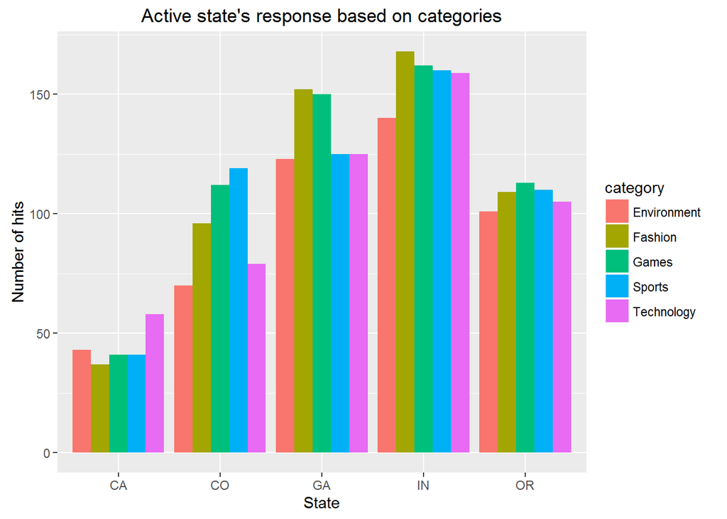

```r
ggplot(data=testData2, aes(x= location.state,  fill= category)) + geom_bar(data=subset(testData2, location.state == c('IN', 'GA', 'OR', 'CO','CA')), stat="count", position = PositionDodge) + xlab("State") + ylab("Number of hits") + ggtitle("Active state's response based on categories")
```

Geographically, top 4 states which funded project are Indiana (IN), Georgia (GA), Oregon (OR) and Colorado (CO). The high response and fund in some states could be high population or some geographical need these products cater to, which requires some additional information.

The most active state in funding projects on Bootloader is **IN**.

### Question 3

**What are some popular traits of a successfully funded project on Bootloader platform?**  
From the above visualization of data, we can say that highly funded project attracts on 18-24 age group, married couple. We have seen that there is almost double response from iOS users, so project should be very friendly to iOS.

```r
subData <- subset(testData1$data, event_name =="Fund Project") #Considering only funded projects
group_by( subData, category,session_id) %>% summarise(newvar = sum(amount)) %>% summarise(newvar2 = sum(newvar), mean = mean(newvar), median =  median(newvar))
```

```
## # A tibble: 5 x 4
##      category newvar2     mean median
##         <chr>   <int>    <dbl>  <dbl>
## 1 Environment  162376 49.86978     44
## 2     Fashion  159952 49.32223     44
## 3       Games  165483 49.39791     44
## 4      Sports  163528 49.61408     44
## 5  Technology  162731 50.10191     44
```

```r
group_by(subData, gender,age) %>% summarise(newvar = sum(amount), mean = mean(amount), sd = sd(amount), median = median(amount))#Mean and median per age group
```

```
## Source: local data frame [10 x 6]
## Groups: gender [?]
##
##    gender   age newvar     mean       sd median
##     <chr> <chr>  <int>    <dbl>    <dbl>  <dbl>
## 1       F 18-24 207423 39.41155 14.71013     39
## 2       F 25-34  49402 39.58494 14.95588     39
## 3       F 35-44  53254 39.53526 15.22381     40
## 4       F 45-54  48761 39.26006 14.51724     39
## 5       F   55+  48636 39.54146 15.35952     40
## 6       M 18-24 203654 39.34583 14.86113     39
## 7       M 25-34  50361 40.35337 15.10421     41
## 8       M 35-44  52343 39.38525 15.27954     40
## 9       M 45-54  49934 38.70853 14.60593     38
## 10      M   55+  50302 39.14553 15.26204     39
```

```r
group_by(subData, marital_status, device) %>% summarise(newvar = sum(amount), mean = mean(amount), sd = sd(amount), median = median(amount))#Mean and median per device user
```

```
## Source: local data frame [4 x 6]
## Groups: marital_status [?]
##
##   marital_status  device newvar     mean       sd median
##            <chr>   <chr>  <int>    <dbl>    <dbl>  <dbl>
## 1        married android 142154 39.11778 14.82333     39
## 2        married     iOS 387501 39.34420 14.97728     39
## 3         single android 141391 39.66087 14.67240     40
## 4         single     iOS 143024 39.61884 15.06525     40
```

Funding is category unbiased because every category has got almost same amount of fund and their mean and median values are almost same. Each category has also received the same number of interactive user IDs.

We can see that median of fund for all age group is same, but there is higher fund available from people of age group of 18-24. Therefore, we can say since there are lots of hits from the age group, most of the projects focus on this age group. There are higher funding events as well from this group so best projects improve themselves constantly so that people can fund them later as well.

Higher funding from Married and iOS users also suggests that successful projects are more focused towards couples and must be easier to interact with on iOS systems.

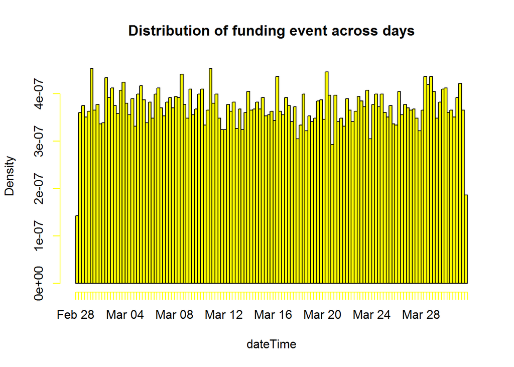

```r
dateTime <- as.POSIXct(subData$client_time, origin="1970-01-01")
hist(dateTime, breaks = 100, col =5, main = "Distribution of funding event across days")
```

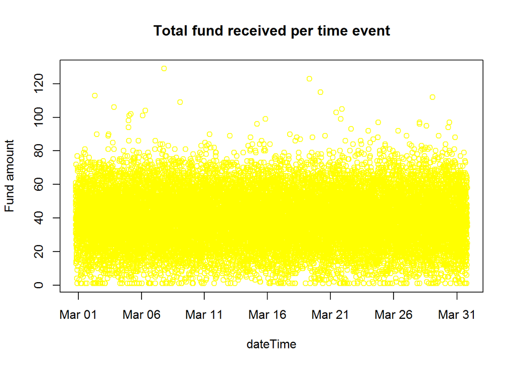

```r
t <- group_by( subData, client_time) %>% summarise(Fund = sum(amount), mean = mean(amount), median =  median(amount))
x <- apply(t[,1], 1, as.numeric)
fund <- apply(t[,2], 1, as.numeric)
x <- as.POSIXct(x, origin="1970-01-01")
plot(x, fund, col = 5, xlab = "dateTime", ylab = "Fund amount", main = "Total fund received per time event" )
```

So, from the graph it appears that there is not a specific day when notification should be sent as there is no variation in funding amount and number of hits across all days.

**Popular traits for successful Bootloader platforms are:**  
1) Age  
2) Location  
3) Operating system  
4) Marital_status

### Question 4

**What are some outlier projects that did very poorly or outperformed everyone?**

```r
group_by( subData, category, session_id) %>% summarise(user_Totalfund = sum(amount)) %>% summarise( total_fund = sum(user_Totalfund), MeanFund = mean(user_Totalfund), MedianFund = median(user_Totalfund), MaxFund = max(user_Totalfund), MinFund = min(user_Totalfund), Fund_sd = sd (user_Totalfund))
```

```
## # A tibble: 5 x 7
##      category total_fund MeanFund MedianFund MaxFund MinFund  Fund_sd
##         <chr>      <int>    <dbl>      <dbl>   <int>   <int>    <dbl>
## 1 Environment     162376 49.86978         44     258       1 27.01453
## 2     Fashion     159952 49.32223         44     237       1 27.48801
## 3       Games     165483 49.39791         44     252       1 26.92235
## 4      Sports     163528 49.61408         44     253       1 27.47572
## 5  Technology     162731 50.10191         44     308       1 28.43988
```

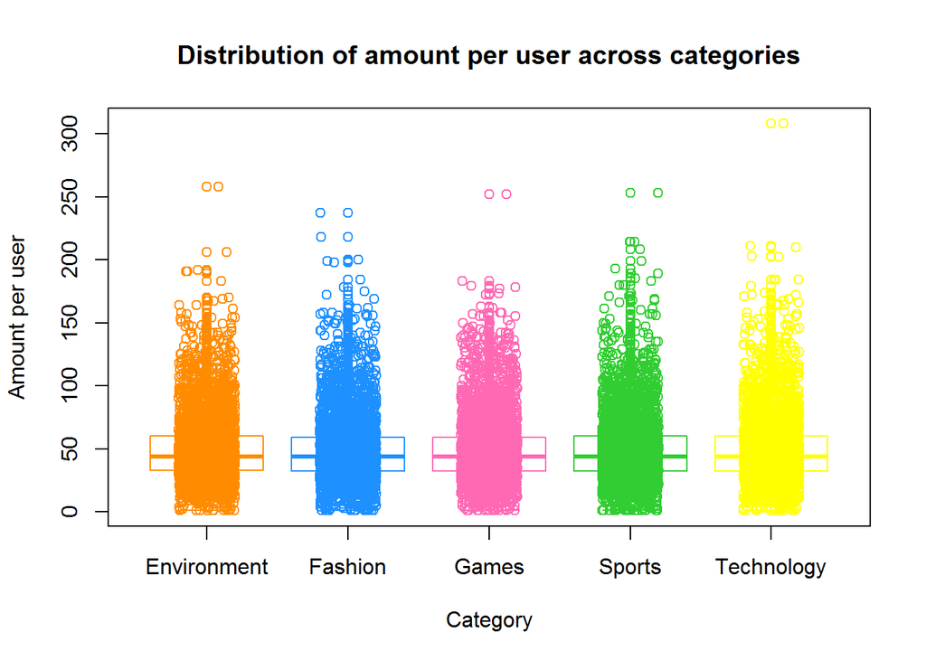

```r
Data_Grp_ID = group_by( subData, category, session_id) %>% summarise(user_Totalfund = sum(amount))

boxplot( Data_Grp_ID$user_Totalfund ~ Data_Grp_ID$category, border = c(1,2,3,4,5), xlab = "Category", ylab = "Amount per user", main = "Distribution of amount per user across categories")

points(Data_Grp_ID$user_Totalfund ~ jitter(as.numeric(as.factor(Data_Grp_ID$category))), col = as.numeric(as.factor(Data_Grp_ID$category)))
```

With the boxplot we can conslude that biggest outlier as per user fund lies in Technology category. so, although Games category has recieved highest amount but Technology category sees largest amount as per individual user’s fund .

### Question 5

**What are the different segments of users who are active on this platform? What are the stats/traits of those segments?**

```r
group_by( testData1$data, event_name, gender, session_id) %>% summarise(FrequencyPerUser = n())%>% summarise(NumberOfUsers = n())
```

```
## Source: local data frame [4 x 3]
## Groups: event_name [?]
##
##     event_name gender NumberOfUsers
##          <chr>  <chr>         <int>
## 1 Fund Project      F          4207
## 2 Fund Project      M          4210
## 3 View Project      F          5246
## 4 View Project      M          5220
```

```r
filter(group_by( testData1$data, event_name, gender, session_id) %>% summarise(AmountPerUser = sum(amount))%>% summarise(AmountPerGender = sum(AmountPerUser), MeanAmountPergender = mean(AmountPerUser), MedianAmountPerGender = median(AmountPerUser)), event_name == "Fund Project")
```

```
## Source: local data frame [2 x 5]
## Groups: event_name [1]
##
##     event_name gender AmountPerGender MeanAmountPergender
##          <chr>  <chr>           <int>               <dbl>
## 1 Fund Project      F          407476            96.85667
## 2 Fund Project      M          406594            96.57815
## # ... with 1 more variables: MedianAmountPerGender <dbl>
```

There is no significant difference in total number of hits across both genders. Mean, median and total amount across each gender group also are same.

```r
group_by( testData1$data, event_name, age, session_id) %>% summarise(FrequencyPerUser = n())%>% summarise(NumberOfUsers = n())
```

```
## Source: local data frame [10 x 3]
## Groups: event_name [?]
##
##      event_name   age NumberOfUsers
##           <chr> <chr>         <int>
## 1  Fund Project 18-24          4271
## 2  Fund Project 25-34          1025
## 3  Fund Project 35-44          1049
## 4  Fund Project 45-54          1038
## 5  Fund Project   55+          1034
## 6  View Project 18-24          4683
## 7  View Project 25-34          1432
## 8  View Project 35-44          1483
## 9  View Project 45-54          1440
## 10 View Project   55+          1428
```

```r
filter(group_by( testData1$data, event_name, age, session_id) %>% summarise(AmountPerUser = sum(amount))%>% summarise(AmountPerAge = sum(AmountPerUser), MeanAmountPerAge = mean(AmountPerUser), MedianAmountPerAge = median(AmountPerUser)), event_name == "Fund Project")
```

```
## Source: local data frame [5 x 5]
## Groups: event_name [1]
##
##     event_name   age AmountPerAge MeanAmountPerAge MedianAmountPerAge
##          <chr> <chr>        <int>            <dbl>              <dbl>
## 1 Fund Project 18-24       411077         96.24842               76.0
## 2 Fund Project 25-34        99763         97.32976               79.0
## 3 Fund Project 35-44       105597        100.66444               83.0
## 4 Fund Project 45-54        98695         95.08189               78.5
## 5 Fund Project   55+        98938         95.68472               77.0
```

We can see that there are higher number of users for age group of 18-24. This plays a significant role in funding. As we can see from second output that although mean and median for Amount per age group are higher for age group of 35-44, total amount per age group for 18-24 comes almost four times of 35-44 as former has higher membership.

```r
group_by( testData1$data, marital_status, device, session_id) %>% summarise(FrequencyPerUser = n())%>% summarise(NumberOfUsers = n())
```

```
## Source: local data frame [4 x 3]
## Groups: marital_status [?]
##
##   marital_status  device NumberOfUsers
##            <chr>   <chr>         <int>
## 1        married android          1903
## 2        married     iOS          4560
## 3         single android          1967
## 4         single     iOS          2036
```

```r
group_by(subData, marital_status, device, session_id) %>% summarise(AmountPerUser = sum(amount), meanPerDevice = mean(amount), medianPerDevice = median(amount))%>% summarise(AmountPerMS = sum(AmountPerUser), MeanAmountPerMS = mean(AmountPerUser), MedianAmountPerMS = median(AmountPerUser))
```

```
## Source: local data frame [4 x 5]
## Groups: marital_status [?]
##
##   marital_status  device AmountPerMS MeanAmountPerMS MedianAmountPerMS
##            <chr>   <chr>       <int>           <dbl>             <dbl>
## 1        married android      142154        98.71806              78.5
## 2        married     iOS      387501        96.77847              78.0
## 3         single android      141391        96.11897              77.0
## 4         single     iOS      143024        95.22237              76.5
```

```r
group_by(subData, marital_status, device, session_id) %>% summarise(AmountPerUser = sum(amount), meanPerDevice = mean(amount), medianPerDevice = median(amount))%>% summarise(AmountPerMS = sum(AmountPerUser), MeanAmountPerMS = mean(AmountPerUser), MedianAmountPerMS = median(AmountPerUser)) %>% summarise(sum(AmountPerMS), mean = mean(AmountPerMS), median = median(AmountPerMS))
```

```
## # A tibble: 2 x 4
##   marital_status sum(AmountPerMS)     mean   median
##            <chr>            <int>    <dbl>    <dbl>
## 1        married           529655 264827.5 264827.5
## 2         single           284415 142207.5 142207.5
```

These stats are similar to what we have observed in age group. Since there are higher number of user population for married and iOS user group. We see higher contribution from married and iOS user group section. In last output we see that married couple are more attracted to projects compared to single persons. As their median value is higher than single ones. So, they contribute more for each project than single persons.  
For location segment, analysis is already presented in question number 2.

```
##  setting  value
##  version  R version 3.3.1 (2016-06-21)
##  system   x86_64, mingw32
##  ui       RTerm
##  language (EN)
##  collate  English_United States.1252
##  tz       America/New_York
##  date     2016-09-09
```

```
## Packages ------------------------------------------------------------------
```

```
##  package    * version date       source
##  assertthat   0.1     2013-12-06 CRAN (R 3.3.1)
##  colorspace   1.2-6   2015-03-11 CRAN (R 3.3.1)
##  DBI        * 0.5     2016-08-11 CRAN (R 3.3.1)
##  devtools     1.12.0  2016-06-24 CRAN (R 3.3.1)
##  digest       0.6.10  2016-08-02 CRAN (R 3.3.1)
##  dplyr      * 0.5.0   2016-06-24 CRAN (R 3.3.1)
##  evaluate     0.9     2016-04-29 CRAN (R 3.3.1)
##  formatR      1.4     2016-05-09 CRAN (R 3.3.1)
##  ggplot2    * 2.1.0   2016-03-01 CRAN (R 3.3.1)
##  gtable       0.2.0   2016-02-26 CRAN (R 3.3.1)
##  htmltools    0.3.5   2016-03-21 CRAN (R 3.3.1)
##  jsonlite   * 1.0     2016-07-01 CRAN (R 3.3.1)
##  knitr        1.14    2016-08-13 CRAN (R 3.3.1)
##  labeling     0.3     2014-08-23 CRAN (R 3.3.1)
##  lazyeval     0.2.0   2016-06-12 CRAN (R 3.3.1)
##  magrittr     1.5     2014-11-22 CRAN (R 3.3.1)
##  memoise      1.0.0   2016-01-29 CRAN (R 3.3.1)
##  munsell      0.4.3   2016-02-13 CRAN (R 3.3.1)
##  plyr         1.8.4   2016-06-08 CRAN (R 3.3.1)
##  R6           2.1.3   2016-08-19 CRAN (R 3.3.1)
##  Rcpp         0.12.6  2016-07-19 CRAN (R 3.3.1)
##  rmarkdown    1.0     2016-07-08 CRAN (R 3.3.1)
##  RMySQL     * 0.10.9  2016-05-08 CRAN (R 3.3.1)
##  scales       0.4.0   2016-02-26 CRAN (R 3.3.1)
##  stringi      1.1.1   2016-05-27 CRAN (R 3.3.0)
##  stringr      1.1.0   2016-08-19 CRAN (R 3.3.1)
##  tibble       1.1     2016-07-04 CRAN (R 3.3.1)
##  tidyjson   * 0.2.1   2015-05-02 CRAN (R 3.3.1)
##  withr        1.0.2   2016-06-20 CRAN (R 3.3.1)
##  yaml         2.1.13  2014-06-12 CRAN (R 3.3.1)
```

### Last compilation

Last compiled at 2016-09-09.